# examples_0413

Solve the equation below.
$$5=\frac{x+9}{4}$$

Rewrite the given equation.
$$5=\frac{x+9}{4}$$
Multiply both sides of the equation by 4.

$$20=x+9$$

Subtract 9 from both sides of the equation.

$$11=x$$

Switch sides (which is allowed because equality is commutative).

$$x=11$$

You can check your possible answer by substituting 11 for $x$ in the original equation.

$$5\stackrel{?}{=}\frac{(11)+9}{4}$$

$$5 \stackrel{?}{=}
\frac{20}{4}$$

$$5 \stackrel{\checkmark}{=}
5$$

So, indeed we see that $x=11$ is a solution to the equation.

Solve the equation below.
$$7=(x-2)\cdot
7$$

Rewrite the given equation.
$$7=(x-2)\cdot
7$$
Divide both sides of the equation by 7.

$$1=x-2$$

Add 2 to both sides of the equation.

$$3=x$$

Switch sides (which is allowed because equality is commutative).

$$x=3$$

You can check your possible answer by substituting 3 for $x$ in the original equation.

$$7\stackrel{?}{=}((3)-2)\cdot
7$$

$$7 \stackrel{?}{=} 1\cdot 7$$

$$7 \stackrel{\checkmark}{=}
7$$

So, indeed we see that $x=3$ is a solution to the equation.

Solve the equation below.
$$2=\frac{x}{2}-3$$

Rewrite the given equation.
$$2=\frac{x}{2}-3$$
Add 3 to both sides of the equation.

$$5=\frac{x}{2}$$

Multiply both sides of the equation by 2.

$$10=x$$

Switch sides (which is allowed because equality is commutative).

$$x=10$$

You can check your possible answer by substituting 10 for $x$ in the original equation.

$$2\stackrel{?}{=}\frac{(10)}{2}-3$$

$$2 \stackrel{?}{=} 5-3$$

$$2 \stackrel{\checkmark}{=}
2$$

So, indeed we see that $x=10$ is a solution to the equation.

Evaluate the expression below.

$$2\cdot 10^{3}+6\cdot 10^{2}+3\cdot
10^{1}+7\cdot 10^{0}$$

This is easier than it looks.

$$2\cdot 10^{3}+6\cdot 10^{2}+3\cdot
10^{1}+7\cdot 10^{0}$$

$$2\cdot 1000+6\cdot 100+3\cdot 10+7\cdot
1$$

$$2000+600+30+7$$

$$2637$$

Evaluate the expression below.

$$5\cdot 10^{3}+4\cdot 10^{2}+7\cdot
10^{1}+8\cdot 10^{0}$$

This is easier than it looks.

$$5\cdot 10^{3}+4\cdot 10^{2}+7\cdot
10^{1}+8\cdot 10^{0}$$

$$5\cdot 1000+4\cdot 100+7\cdot 10+8\cdot
1$$

$$5000+400+70+8$$

$$5478$$

Evaluate the expression below.

$$9\cdot 10^{4}+8\cdot 10^{3}+2\cdot
10^{2}+6\cdot 10^{1}+4\cdot 10^{0}$$

This is easier than it looks.

$$9\cdot 10^{4}+8\cdot 10^{3}+2\cdot
10^{2}+6\cdot 10^{1}+4\cdot 10^{0}$$

$$9\cdot 10000+8\cdot 1000+2\cdot
100+6\cdot 10+4\cdot 1$$

$$90000+8000+200+60+4$$

$$98264$$

As an alien-human translator, you run into this alien number:

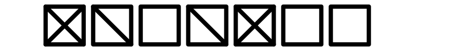

What number is represented (expressed in our base-10 human way)?

Each symbol represents a 0, 1, or a 2. Each placement represents a power of 3. The total value is found by adding up the products of each symbol's value times its corresponding power of 3.

$$2\cdot 3^{6}+1\cdot 3^{5}+0\cdot
3^{4}+1\cdot 3^{3}+2\cdot 3^{2}+0\cdot 3^{1}+0\cdot 3^{0}$$

You should get the answer:

$$1746$$

As an alien-human translator, you run into this alien number:

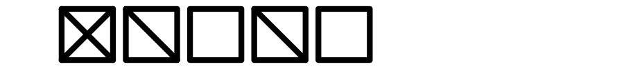

What number is represented (expressed in our base-10 human way)?

Each symbol represents a 0, 1, or a 2. Each placement represents a power of 3. The total value is found by adding up the products of each symbol's value times its corresponding power of 3.

$$2\cdot 3^{4}+1\cdot 3^{3}+0\cdot
3^{2}+1\cdot 3^{1}+0\cdot 3^{0}$$

You should get the answer:

$$192$$

As an alien-human translator, you run into this alien number:

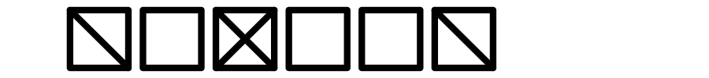

What number is represented (expressed in our base-10 human way)?

Each symbol represents a 0, 1, or a 2. Each placement represents a power of 3. The total value is found by adding up the products of each symbol's value times its corresponding power of 3.

$$1\cdot 3^{5}+0\cdot 3^{4}+2\cdot
3^{3}+0\cdot 3^{2}+0\cdot 3^{1}+1\cdot 3^{0}$$

You should get the answer:

$$298$$

As an alien-human translator, you run into this alien number:

[figure not shown]

What number is represented (expressed in our base-10 human way)?

Each symbol represents a number between 0 and 3. Each position represents a power of 4. The total value is found by adding up the products of each symbol's value times its corresponding power of 4.

$$2\cdot 4^{6}+3\cdot 4^{5}+1\cdot
4^{4}+2\cdot 4^{3}+0\cdot 4^{2}+0\cdot 4^{1}+2\cdot 4^{0}$$

You should get the answer:

$$11650$$

As an alien-human translator, you run into this alien number:

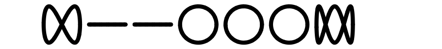

What number is represented (expressed in our base-10 human way)?

Each symbol represents a number between 0 and 3. Each position represents a power of 4. The total value is found by adding up the products of each symbol's value times its corresponding power of 4.

$$2\cdot 4^{6}+0\cdot 4^{5}+0\cdot
4^{4}+1\cdot 4^{3}+1\cdot 4^{2}+1\cdot 4^{1}+3\cdot 4^{0}$$

You should get the answer:

$$8279$$

As an alien-human translator, you run into this alien number:

[figure not shown]

What number is represented (expressed in our base-10 human way)?

Each symbol represents a number between 0 and 3. Each position represents a power of 4. The total value is found by adding up the products of each symbol's value times its corresponding power of 4.

$$1\cdot 4^{5}+3\cdot 4^{4}+2\cdot
4^{3}+0\cdot 4^{2}+0\cdot 4^{1}+0\cdot 4^{0}$$

You should get the answer:

$$1920$$

As an alien-human translator, you run into this alien number:

[figure not shown]

What number is represented (expressed in our base-10 human way)?

Each symbol represents a number between 0 and 4. Each position represents a power of 5. The total value is found by adding up the products of each symbol's value times its corresponding power of 5.

$$4\cdot 5^{6}+2\cdot 5^{5}+1\cdot
5^{4}+3\cdot 5^{3}+0\cdot 5^{2}+4\cdot 5^{1}+4\cdot 5^{0}$$

You should get the answer:

$$69774$$

As an alien-human translator, you run into this alien number:

[figure not shown]

What number is represented (expressed in our base-10 human way)?

Each symbol represents a number between 0 and 4. Each position represents a power of 5. The total value is found by adding up the products of each symbol's value times its corresponding power of 5.

$$2\cdot 5^{6}+4\cdot 5^{5}+0\cdot
5^{4}+2\cdot 5^{3}+1\cdot 5^{2}+3\cdot 5^{1}+4\cdot 5^{0}$$

You should get the answer:

$$44044$$

As an alien-human translator, you run into this alien number:

[figure not shown]

What number is represented (expressed in our base-10 human way)?

Each symbol represents a number between 0 and 4. Each position represents a power of 5. The total value is found by adding up the products of each symbol's value times its corresponding power of 5.

$$4\cdot 5^{6}+2\cdot 5^{5}+0\cdot
5^{4}+3\cdot 5^{3}+2\cdot 5^{2}+4\cdot 5^{1}+1\cdot 5^{0}$$

You should get the answer:

$$69196$$

As an alien-human translator, you run into this alien number:

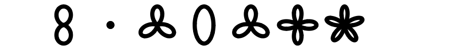

What number is represented (expressed in our base-10 human way)?

Each symbol represents a number between 0 and 5. Each position represents a power of 6. The total value is found by adding up the products of each symbol's value times its corresponding power of 6.

$$2\cdot 6^{6}+0\cdot 6^{5}+3\cdot
6^{4}+1\cdot 6^{3}+3\cdot 6^{2}+4\cdot 6^{1}+5\cdot 6^{0}$$

You should get the answer:

$$97553$$

As an alien-human translator, you run into this alien number:

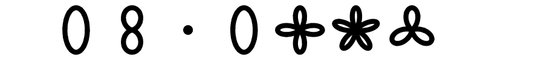

What number is represented (expressed in our base-10 human way)?

Each symbol represents a number between 0 and 5. Each position represents a power of 6. The total value is found by adding up the products of each symbol's value times its corresponding power of 6.

$$1\cdot 6^{6}+2\cdot 6^{5}+0\cdot
6^{4}+1\cdot 6^{3}+4\cdot 6^{2}+5\cdot 6^{1}+3\cdot 6^{0}$$

You should get the answer:

$$62601$$

As an alien-human translator, you run into this alien number:

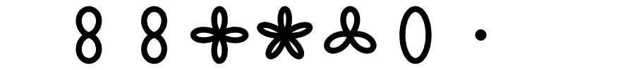

What number is represented (expressed in our base-10 human way)?

Each symbol represents a number between 0 and 5. Each position represents a power of 6. The total value is found by adding up the products of each symbol's value times its corresponding power of 6.

$$2\cdot 6^{6}+2\cdot 6^{5}+4\cdot
6^{4}+5\cdot 6^{3}+3\cdot 6^{2}+1\cdot 6^{1}+0\cdot 6^{0}$$

You should get the answer:

$$115242$$

Consider the base-12 number system from [Schoolhouse Rock's Little Twelvetoes](https://www.youtube.com/watch?v=pqGyUvZP0Zg).

As an alien-human translator, you run into this alien number:

[figure not shown]

What number is represented (expressed in our base-10 human way)?

Each symbol represents a number between 0 and 11. Each position represents a power of 12. The total value is found by adding up the products of each symbol's value times its corresponding power of 12.

$$5\cdot 12^{3}+3\cdot 12^{2}+10\cdot
12^{1}+7\cdot 12^{0}$$

You should get the answer:

$$9199$$

Consider the base-12 number system from [Schoolhouse Rock's Little Twelvetoes](https://www.youtube.com/watch?v=pqGyUvZP0Zg).

As an alien-human translator, you run into this alien number:

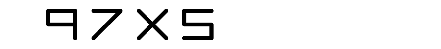

What number is represented (expressed in our base-10 human way)?

Each symbol represents a number between 0 and 11. Each position represents a power of 12. The total value is found by adding up the products of each symbol's value times its corresponding power of 12.

$$9\cdot 12^{3}+7\cdot 12^{2}+10\cdot
12^{1}+5\cdot 12^{0}$$

You should get the answer:

$$16685$$

Consider the base-12 number system from [Schoolhouse Rock's Little Twelvetoes](https://www.youtube.com/watch?v=pqGyUvZP0Zg).

As an alien-human translator, you run into this alien number:

[figure not shown]

What number is represented (expressed in our base-10 human way)?

Each symbol represents a number between 0 and 11. Each position represents a power of 12. The total value is found by adding up the products of each symbol's value times its corresponding power of 12.

$$8\cdot 12^{3}+0\cdot 12^{2}+10\cdot
12^{1}+4\cdot 12^{0}$$

You should get the answer:

$$13948$$